# ta1

Causal Inference & ML

TA Session 1

Data Science for Decision Making

Lucia Sauer

2026-01-30

# TA Materials:

All the material for TA Sessions — slides, and code will be hosted in the [GitHub repository](https://github.com/luciasauer/bse_causal_inference_ml).

```bash
git clone https://github.com/luciasauer/bse_causal_inference_ml.git
```

The TA sessions will mainly focus on **Stata**, but some examples in **Python** will also be provided.

📦 Ensure that the required Python packages are installed:

Install uv

```bash
uv sync
```

Pull the repository and get the updated materials for each session.

# Outline

- Panel Data
- Why Panel Data?
- Static and Linear Models
  - Pooled OLS
  - Fixed Effects Models
  - Random Effects Models
  - Hausman Test
- Dynamic Panel Data Models
  - Arellano-Bond Estimator

# What panel data looks like…

- Panel data consists of observations on multiple entities over multiple time periods.
- Each entity is observed at several time points, allowing us to analyze changes over time within the same entities.

| Entity ID | Time Period | Income | gender |
| --- | --- | --- | --- |
| 1 | 2000 | 30 | male |
| 1 | 2001 | 33 | male |
| 1 | 2002 | 33 | male |
| 2 | 2000 | 50 | female |
| 2 | 2001 | 58 | female |
| 2 | 2002 | 61 | female |
| 3 | 2000 | 25 | female |
| 3 | 2001 | 30 | female |
| 3 | 2002 | 42 | female |

## Wide Format Panel Data

- In practice, datasets such as those from the World Bank are typically organized in **wide format.**
- To perform panel data analysis, we first reshape the data into **long format**, so that each row corresponds to a specific entity and time period.

|  | Country | 2000 | 2001 | 2002 | 2003 | 2004 | 2005 |
| --- | --- | --- | --- | --- | --- | --- | --- |
| 0 | A | 4058.14 | 4093.61 | 4821.78 | 4430.52 | 4981.48 | 3668.82 |
| 1 | B | 23692.66 | 24545.37 | 25319.78 | 24818.70 | 25805.80 | 27093.83 |
| 2 | C | 15288.34 | 14714.42 | 15167.32 | 15475.99 | 15806.36 | 17222.30 |
| 3 | D | 22256.36 | 23299.13 | 23038.89 | 23134.99 | 24062.82 | 25342.87 |
| 4 | E | 29145.24 | 30223.65 | 31543.82 | 31838.64 | 33580.40 | 34576.21 |
| 5 | F | 17686.25 | 17625.59 | 18690.89 | 18853.40 | 18500.80 | 20593.65 |

## Long Format Panel Data

Stata use the command `reshape` to convert wide format data to long format:

```stata
gen id = _n
order id
reshape long x , i(id) j(year)
```

In Python we can use the `melt` function in pandas:

```python
long = (
    wide.melt("Country", var_name="year", value_name="gdp")
        .assign(year=lambda d: d.year.astype(int))
)
long = long.sort_values(["Country", "year"])
```

|  | Country | year | gdp |
| --- | --- | --- | --- |
| 0 | A | 2000 | 4058.14 |
| 7 | A | 2001 | 4093.61 |
| 14 | A | 2002 | 4821.78 |
| 21 | A | 2003 | 4430.52 |

# Types of Panel Data

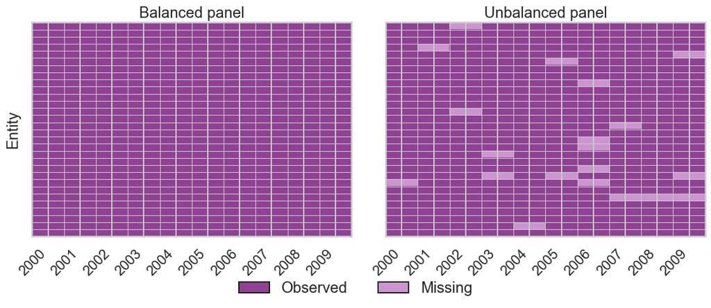

Usefull package in R to plot panel data structure: `panelview`

# Types of Panel Data

Micro panels: Large $N=50$, Small $T=10$

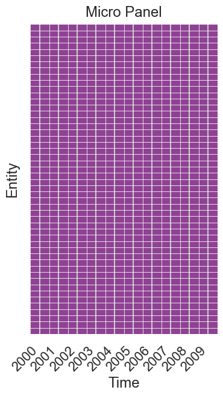

# Types of Panel Data

Macro panels: small $N=10$ and large $T=50$

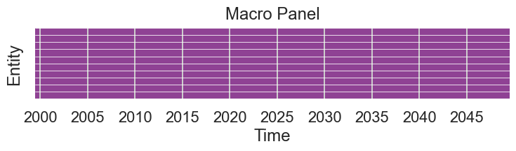

# Why Panel Data?

The problem

OLS requires exogeneity: $E(u_{it} \mid X_{it}) = 0$

When unobserved factors $(c_i)$ affect $(y_{it})$ and are correlated with $(X_{it})$,
$$\text{Cov}(X_{it}, c_i) \neq 0$$
OLS suffers from **Omitted Variable Bias**.

- **With a single cross section**, some remedies are Instrumental Variables (IV)
- **With panel data**, we can control for **time-invariant unobserved heterogeneity**

[figure not shown]

# Panel Data Models

Throughout this session, we focus on **panel data models** designed to handle unobserved heterogeneity and dynamic behavior over time.

1. Static Linear Panel Models

- **Pooled OLS** — Ignores unobserved heterogeneity
- **Fixed Effects (FE)** — Allows $\text{Cov}(c_i, X_{it}) \neq 0$
- **Random Effects (RE)** — Requires $\text{Cov}(c_i, X_{it}) = 0$

2. Dynamic Panel Models

- Arellano–Bond (Difference GMM)
- System GMM

Used when the model includes **lagged dependent variables** and standard FE is biased.

# 1. Static and Linear Models

## The Grunfeld Investment Data

We use the classic [**Grunfeld (1958)**](https://www.stata-press.com/data/r18/grunfeld.dta) dataset, which contains annual data on 10 large US manufacturing firms from 1935 to 1954.

To access the data in Stata, use:

```stata
webuse grunfeld, clear
```

In Python:

```python
grunfeld = pd.read_stata("data/grunfeld.dta")
grunfeld.head(5)
```

|  | company | year | invest | mvalue | kstock | time |
| --- | --- | --- | --- | --- | --- | --- |
| 0 | 1 | 1935-01-01 | 317.600006 | 3078.500000 | 2.800000 | 1 |
| 1 | 1 | 1936-01-01 | 391.799988 | 4661.700195 | 52.599998 | 2 |
| 2 | 1 | 1937-01-01 | 410.600006 | 5387.100098 | 156.899994 | 3 |
| 3 | 1 | 1938-01-01 | 257.700012 | 2792.199951 | 209.199997 | 4 |
| 4 | 1 | 1939-01-01 | 330.799988 | 4313.200195 | 203.399994 | 5 |

## The model

We want to model the investment behavior of firms over time:
$$invest_{it} = \beta_0 + \beta_1 mvalue_{i,t-1} + \beta_2 kstock_{i,t-1} + c_i + \varepsilon_{it}$$

- $invest_{it}$: Investment (current year)
- $mvalue_{i,t-1}$: Market value of the firm (end of previous year)
- $kstock_{i,t-1}$: Capital stock (end of previous year)
- $c_i$: Unobserved time-invariant firm-specific heterogeneity (e.g., management quality, corporate culture, industry position).

Research question

How do market value and capital stock affect firm investment?

## Setting Up the Panel Structure

In Stata, we declare the panel structure using the `xtset` command:

```stata
xtset company year
```

```
Panel variable: company (strongly balanced)
 Time variable: year, 1935 to 1954
         Delta: 1 year
```

Interpretation: we have a *strongly balanced* panel — all 10 firms are observed in all 20 years, giving us $N = 10 \times 20 = 200$ observations.

In Python, we can set the index to be a MultiIndex with company and year:

```python
grunfeld = grunfeld.set_index(['company', 'year'])
```

## Descriptive Statistics

In Stata we can explore pooled summary statistics with the `summarize` command:

```stata
summarize invest mvalue kstock
```

```
    Variable |        Obs        Mean    Std. dev.       Min        Max
-------------+---------------------------------------------------------
      invest |        200    145.9583    216.8753        .93     1486.7
      mvalue |        200    1081.681     1314.47      58.12     6241.7
      kstock |        200    276.0172    301.1039         .8     2226.3
```

In Python, we can compute the same summary statistics using the `describe` method:

```python
grunfeld.reset_index()[['invest', 'mvalue', 'kstock']].describe()
```

|  | invest | mvalue | kstock |
| --- | --- | --- | --- |
| count | 200.000000 | 200.000000 | 200.000000 |
| mean | 145.958237 | 1081.681152 | 276.017151 |
| std | 216.875290 | 1314.469727 | 301.103912 |
| min | 0.930000 | 58.119999 | 0.800000 |
| 25% | 33.557499 | 199.975006 | 79.174999 |
| 50% | 57.485001 | 517.950012 | 205.599998 |
| 75% | 138.040001 | 1679.850006 | 358.099991 |
| max | 1486.699951 | 6241.700195 | 2226.300049 |

## Sources of variation in Panel Data

A key feature of panel data is that variation comes from 2 sources:

$$\text{between} = \bar{Y}_{i} - \bar{Y} \quad \text{and} \quad \text{within} = Y_{it} - \bar{Y}_i$$

Simplified example with only 3 firms over 3 years:

| company | year | $invest_{it}$ | $\bar{invest}_i$ | $invest_{it}-\bar{invest}$ | **$invest_{it}-\bar{invest}_i$** | $\bar{invest}_i-\bar{invest}$ |
| --- | --- | --- | --- | --- | --- | --- |
| 1 | 1935 | 317.6 | 373.33 | 60.89 | **−55.73** | 116.62 |
| 1 | 1936 | 391.8 | 373.33 | 135.09 | **18.47** | 116.62 |
| 1 | 1937 | 410.6 | 373.33 | 153.89 | **37.27** | 116.62 |
| 2 | 1935 | 209.9 | 345.03 | −46.81 | **−135.13** | 88.32 |
| 2 | 1936 | 355.3 | 345.03 | 98.59 | **10.27** | 88.32 |
| 2 | 1937 | 469.9 | 345.03 | 213.19 | **124.87** | 88.32 |
| 3 | 1935 | 33.1 | 51.77 | −223.61 | **−18.67** | −204.94 |
| 3 | 1936 | 45.0 | 51.77 | −211.71 | **−6.77** | −204.94 |
| 3 | 1937 | 77.2 | 51.77 | −179.51 | **25.43** | −204.94 |

## Within and Between Variation

This can be summarized using the `xtsum` command in Stata:

```stata
xtsum invest mvalue kstock
```

```
Variable         |      Mean   Std. dev.       Min        Max |    Observations
-----------------+--------------------------------------------+----------------
invest   overall |  145.9583   216.8753        .93     1486.7 |     N =     200
         between |             198.8242     3.0845     608.02 |     n =      10
         within  |             106.1986  -204.3617   1024.638 |     T =      20
                 |                                            |
mvalue   overall |  1081.681    1314.47      58.12     6241.7 |     N =     200
         between |             1334.917     70.921   4333.845 |     n =      10
         within  |             340.5421   -459.964   2989.536 |     T =      20
                 |                                            |
kstock   overall |  276.0172   301.1039         .8     2226.3 |     N =     200
         between |             200.9701     5.9415    648.435 |     n =      10
         within  |             232.6603  -369.6179   1853.882 |     T =      20
```

Interpretation:

- For $invest$: between-firm SD (198) $>$ within-firm SD (106). Most variation is across firms, not within firms over time.
- This suggests that firm-specific characteristics (captured by $c_i$) are important.
- Fixed effects will exploit only the within variation; random effects uses both.

## Estimation Methods - Pooled OLS

First Case

- Pooled OLS ignores unobserved heterogeneity and pools all observations together.
- It assumes that $c_i = c \quad \text{is constant}$
- If $c_i$ is correlated with $mvalue$ or $kstock$, estimates are **biased**.

In Stata, we can estimate the pooled OLS model using the `reg` command with robust standard errors because of potential heteroskedasticity:

```stata
reg invest mvalue kstock, robust
```

```
Linear regression                               Number of obs     =        200
                                                F(2, 197)         =     178.83
                                                Prob > F          =     0.0000
                                                R-squared         =     0.8124
                                                Root MSE          =     94.408
------------------------------------------------------------------------------
             |               Robust
      invest | Coefficient  std. err.      t    P>|t|     [95% conf. interval]
-------------+----------------------------------------------------------------
      mvalue |   .1155622    .006811    16.97   0.000     .1021304    .1289939
      kstock |   .2306785   .0488655     4.72   0.000     .1343118    .3270452
       _cons |  -42.71437    11.5747    -3.69   0.000    -65.54059   -19.88815
------------------------------------------------------------------------------
```

## Estimation Methods - Fixed Effects (Within Estimator)

1. We start from the panel data model:

$$invest_{it} = c_i + \beta_1 mvalue_{i,t-1}+ \beta_2 kstock_{i,t-1} + \varepsilon_{it}$$

where we allow for $c_i$ to be correlated with $mvalue$ and $kstock$, random and unobserved.

2. Fixed Effects removes $c_i$ by comparing each unit **to itself over time**.

$$invest_{it} - \bar{invest}_i = \beta_1 (mvalue_{i,t-1} - \bar{mvalue}_i) + \beta_2 (kstock_{i,t-1} - \bar{kstock}_i) + (\varepsilon_{it} - \bar{\varepsilon}_i)$$

3. Apply OLS to the demeaned variables.

[figure not shown]

## Estimation Methods - Fixed Effects (Within Estimator)

All these steps are done automatically in Stata with the `xtreg, fe` command.

```stata
xtreg invest mvalue kstock, fe robust
```

Also if we want to estimate FE by Dummy Variable approach:

```stata
reg invest mvalue kstock i.company, vce(cluster company)
```

To implement FE - Within Estimator in Python, we can use the `linearmodels.panel` package:

```python
from linearmodels.panel import PanelOLS
fe_model = PanelOLS.from_formula(
    'invest ~ 1 + mvalue + kstock + EntityEffects',
    data=grunfeld
)
fe_results = fe_model.fit(cov_type='clustered', cluster_entity=True)
print(fe_results)
```

## Interpretation of Fixed Effects Results

```
Fixed-effects (within) regression               Number of obs     =        200
Group variable: company                         Number of groups  =         10

R-squared:                                      Obs per group:
     Within  = 0.7668                                         min =         20
     Between = 0.8194                                         avg =       20.0
     Overall = 0.8060                                         max =         20

                                                F(2, 9)           =      28.31
corr(u_i, Xb) = -0.1517                         Prob > F          =     0.0001

                               (Std. err. adjusted for 10 clusters in company)
------------------------------------------------------------------------------
             |               Robust
      invest | Coefficient  std. err.      t    P>|t|     [95% conf. interval]
-------------+----------------------------------------------------------------
      mvalue |   .1101238   .0151945     7.25   0.000     .0757515    .1444961
      kstock |   .3100653   .0527518     5.88   0.000     .1907325    .4293981
       _cons |  -58.74393   27.60286    -2.13   0.062    -121.1859    3.698079
-------------+----------------------------------------------------------------
     sigma_u |  85.732501
     sigma_e |  52.767964
         rho |  .72525012   (fraction of variance due to u_i)
------------------------------------------------------------------------------
```

- $mvalue$: A $\$1$ million increase in market value is associated with a $\$0.11$ million increase in investment.
- $kstock$: A $\$1$ million increase in capital stock is associated with a $\$0.31$ million increase in investment.

## Estimation Methods - Random Effects Model

```stata
xtreg invest mvalue kstock, re robust
```

```
Random-effects GLS regression                   Number of obs     =        200
Group variable: company                         Number of groups  =         10
R-squared:                                      Obs per group:
     Within  = 0.7668                                         min =         20
     Between = 0.8196                                         avg =       20.0
     Overall = 0.8061                                         max =         20
                                                Wald chi2(2)      =      70.13
corr(u_i, X) = 0 (assumed)                      Prob > chi2       =     0.0000

                               (Std. err. adjusted for 10 clusters in company)
------------------------------------------------------------------------------
             |               Robust
      invest | Coefficient  std. err.      z    P>|z|     [95% conf. interval]
-------------+----------------------------------------------------------------
      mvalue |   .1097811   .0137557     7.98   0.000     .0828206    .1367417
      kstock |    .308113   .0549728     5.60   0.000     .2003683    .4158576
       _cons |  -57.83441   24.84323    -2.33   0.020    -106.5262   -9.142576
-------------+----------------------------------------------------------------
     sigma_u |   84.20095
     sigma_e |  52.767964
         rho |  .71800838   (fraction of variance due to u_i)
------------------------------------------------------------------------------
```

- RE assumes $\text{Cov}(c_i, X_{it}) = 0$.
- The Hausman test will help us choose between FE and RE.

## Fixed Effects vs. Random Effects: The Hausman Test

The Hausman test compares the FE and RE estimators.

$$\begin{aligned}
H_0 &: \ \operatorname{Cov}(c_i, X_{it}) = 0
&& \text{(both estimators are consistent, RE is more efficient)} \\
H_A &: \ \operatorname{Cov}(c_i, X_{it}) \neq 0
&& \text{(only FE is consistent)}
\end{aligned}$$

Statistic:

$$H = (\hat{\beta}_{RE} - \hat{\beta}_{FE})' [\operatorname{Var}(\hat{\beta}_{FE}) - \operatorname{Var}(\hat{\beta}_{RE})]^{-1} (\hat{\beta}_{RE} - \hat{\beta}_{FE})$$

This statistic follows a chi-squared distribution under the null hypothesis and RE1 - RE3.

- If $H$ is large, then there is a statistical difference between these two estimators, and we reject $H_0$ in favor of FE.
- If $H$ is small, we fail to reject $H_0$ and prefer RE for efficiency.

## The Hausman Test in Stata

In Stata, we can perform the Hausman test with `hausman` command

1. Estimate and store the FE model

```stata
quietly xtreg invest mvalue kstock, fe
estimates store FE
```

2. Estimate and store the RE model

```stata
quietly xtreg invest mvalue kstock, re
estimates store RE
```

3. Run the Hausman test

```stata
* Hausman test
hausman FE RE, sigmamore
```

- However, this test assumes homoskedasticity and no clustering. If these assumptions are violated, the standard Hausman test may be invalid.
- In such cases, consider using robust or clustered versions of the Hausman test, with `xtoverid` command.
- Nevertheless, FE is often preferred in practice due to is consistent whether or not $\text{Cov}(c_i, X_{it}) = 0$.

## Clustered Standard Errors: Why and How

In panel data, observations within the same entity (firm, country, individual) are typically **not independent**. This violates a key OLS assumption and causes problems:

- **Heteroskedasticity**: Error variance may differ across entities
- **Serial correlation**: Errors for the same entity are correlated over time

For pooled OLS:

```stata
*Hetertoskedastic robust SE
reg invest mvalue kstock, robust

* Cluster-robust: handles BOTH heteroskedasticity AND serial correlation
reg invest mvalue kstock, vce(cluster company)
```

For FE and RE models:

```stata
*Hetertoskedastic robust SE
xtreg invest mvalue kstock, fe robust

* Cluster-robust: handles BOTH heteroskedasticity AND serial correlation
xtreg invest mvalue kstock, fe vce(cluster company)
```

Point estimates remain the same; only standard errors and inference change.

## How many clusters are enough?

Cluster-robust standard errors rely on asymptotic theory as the number of clusters $G \to \infty$. With few clusters:

- **$G \geq 50$** → generally safe
- **$20 \leq G < 50$** → use with caution
- **$G < 20$** → clustered SEs may be unreliable

👉 *Grunfeld data:* **$G = 10$ firms** $\rightarrow$ inference is fragile

**With few clusters:** use wild cluster bootstrap

```stata
* Wild cluster bootstrap (requires boottest package)
ssc install boottest
xtreg invest mvalue kstock, fe
boottest mvalue, cluster(company) reps(999)
```

**Multiple clustering dimensions:**

The `reghdfe` command allows for multiple fixed effects and multi-way clustered standard errors in a computationally efficient way.

```stata
reghdfe invest mvalue kstock, absorb(company) vce(cluster company year)
```

## Adding Time Fixed Effects: Two-Way Fixed Effects

There may be common shocks affecting all entities in a given time period (e.g., economic crises, policy changes). To control for these, we can include time fixed effects:

```stata
xtreg invest mvalue kstock i.year, fe robust
```

Testing for Time Fixed Effects

```stata
testparm i.year
```

```
F(  9,     9) =    6.15
            Prob > F =    0.0062
```

**Interpretation:** The null hypothesis is significant at the $0.6\%$, meaning that year coefficients are jointly statistically significant. Time fixed effects are necessary for this dataset.

# 2. Dynamic Models

## Introduction to Dynamic Panel Data Models

In this section, we’ll understand why lagged dependent variables break our usual toolkit and how GMM methods solve this problem.

Follwoing Arellano and Bond (1991), we will estimate a dynamic labor demand model using use `abdata` dataset of UK firms from 1976 to 1984.

**The model:**
$$n_{it} = c_i + \rho \cdot n_{it-1} + X_{it}'\cdot \beta + \epsilon_{it}$$

where:

- $n_{it}$: log employment
- $\rho$: **persistence parameter** (key!)
- $c_i$: firm fixed effect
- $X_{it}$: wages, capital, output in log (current and lagged)

# Ignoring Dynamic Panel Structure

## Approach 1: Pooled OLS

**Ignore panel structure, estimate:**
$$n_{it} = c_i + \rho \cdot n_{it-1} + X_{it}'\cdot \beta + u_{it}$$

```stata
reg n nL1 nL2 w wL1 k kL1 kL2 ys ysL1 ysL2 yr*, cluster(id)
```

**Problem:** The composite error $u_{it} = c_i + \epsilon_{it}$ contains $c_i$ (productivity, management quality…)

- If $c_i$ is correlated with $n_{it-1}$ $\rightarrow$ **OVB**
- Typically: more productive firms $\rightarrow$ hire more $\rightarrow$ $Cov(n_{it-1}, c_i) > 0$
- Result: $\hat{\rho}_{OLS}$ is **biased upward** ⬆️

**$\hat{\rho} = 1.044$ (>1 !)** — Not plausible for a stationary series!

## Approach 2: Random Effects

**Assume $cov(c_i, X_{it}) = 0$:**

```stata
xtreg n nL1 nL2 w wL1 k kL1 kL2 ys ysL1 ysL2 yr*, re
```

**Problem: Same as OLS!**

Even if $c_i$ were truly random (questionable!):

- $n_{it-1}$ is mechanically correlated with $c_i$
- Because $n_{it-1} = c_i + \rho n_{it-2} + \ldots$
- RE estimator is **inconsistent**

**$\hat{\rho} = 1.044$** — Same as pooled OLS!

## Approach 3: Fixed Effects (Within)

**Demean to eliminate $c_i$:**
$$n_{it} - \bar{n}_i = \rho(n_{it-1} - \bar{n}_i) + (X_{it} - \bar{X}_i)'\beta + (\epsilon_{it} - \bar{\epsilon}_i)$$

```stata
xtreg n nL1 nL2 w wL1 k kL1 kL2 ys ysL1 ysL2 yr*, fe cluster(id)
```

**Problem: Nickell Bias**

After demeaning:

- $(n_{it-1} - \bar{n}_i)$ is correlated with $(\epsilon_{it} - \bar{\epsilon}_i)$
- Why? Because $\bar{n}_i = \frac{1}{T}\sum_{s=1}^T n_{is}$ includes $n_{it}$, which contains $\epsilon_{it}$
- Result: $\hat{\rho}_{FE}= 0.732$ is **biased downward** ⬇️

$$\text{Nickell Bias} \approx -\frac{1+\rho}{T-1} \approx -\frac{1+0.8}{9-1} \approx -0.225$$

## Solution: Arellano-Bond and System GMM

To address the **Nickell bias**, Arellano and Bond proposed the Arellano-Bond estimator, which uses a Generalized Method of Moments (GMM) approach.

1. **First Difference** to eliminate $c_i$:

$$\Delta n_{it} = \rho \Delta n_{it-1} + \Delta X_{it}'\beta + \Delta \epsilon_{it}$$

2. **Problem remains**: $\Delta n_{it-1}$ is correlated with $\Delta \epsilon_{it}$
   - Because $\Delta n_{it-1} = n_{it-1} - n_{it-2}$ contains $\epsilon_{it-1}$
   - And $\Delta \epsilon_{it} = \epsilon_{it} - \epsilon_{it-1}$ also contains $\epsilon_{it-1}$
3. **Solution**: Use **lags in levels** as instruments!

   $$E[n_{it-s} \cdot \Delta\epsilon_{it}] = 0 \quad \text{for } s \geq 2$$
- **Relevance**: $n_{it-2}$ is correlated with $\Delta n_{it-1}$ ✓
- **Exogeneity**: $n_{it-2}$ is **not** correlated with $\Delta\epsilon_{it} = \epsilon_{it} - \epsilon_{it-1}$

## Stata Implementation

To implement Arellano-Bond in Stata, we use the `xtabond2`

```stata
// Arellano-Bond estimation
xtabond2 n nL1 nL2 w wL1 k kL1 kL2 ys ysL1 ysL2 yr*, ///
    gmm(L.(n w k), lag(2 .)) ///      // Treat as endogenous, lags 2+
    iv(L(0/2).ys yr*) ///              // Treat as exogenous
    noleveleq ///                       // Difference GMM only
    robust ///                          // Robust standard errors
    small                               // Small sample correction
```

**Key Options**

- `gmm(L.(n w k), lag(2 .))`: Use lags 2, 3, … as instruments
- `iv(L(0/2).ys yr*)`: Exogenous variables (standard instruments)
- `noleveleq`: Exclude level equation (pure Difference GMM)

## Results

Comparing the estimates:

| Variable | Pooled OLS | Random Effects | Fixed Effects | Arellano–Bond |
| --- | --- | --- | --- | --- |
| nL1 | 1.044*** | 1.044*** | 0.732*** | 0.817*** |

1. $\hat{\rho}_{AB} = 0.817$ lies between FE (0.732) and OLS (1.044) ✓

   $$\hat{\rho}_{fe} < \hat{\rho}_{ab} < \hat{\rho}_{pooled, re}$$
2. Implies **strong employment persistence** (elasticity = 0.82)
3. AR(2) test: p = 0.307 → No second-order correlation ✓
4. Hansen test: p = 0.174 → Instruments are valid ✓

**Why AB is in the middle:**

- **Removes upward bias**: First differences eliminate $c_i$
- **Removes downward bias**: Instruments break the mechanical correlation